# South Florida Coastal Salinity Status

Point of Contact: Paul Julian (Paul.Julian@FloridaDEP.gov) and Alyssa Gilhooly (Alyssa.Gilhooly@FloridaDEP.gov)

Updated 2020-12-04 10:36:24

This webpage is intended to inform Agency representatives on Stage elevation in Lake Okeechobee and status and condition of the Caloosahatchee Estuary, St. Lucie Estuary, and Florida Bay.

*Please note this analysis is using preliminary data and subject to change.*

### *Lake Okeechobee Stage Elevation*

- As of 12/03/2020 the mean stage elevation in Lake Okeechobee is within the Operational Low Sub- Management Band at a stage elevation of 15.99 feet (NGVD29).
- The 7-day recession/accession rate of Lake Okeechobee for 12/03/2020 is -0.19 feet per 7-day period (**NOTE: negative values indicate falling water levels (recession) and positive values indicate raising water level (ascension)**). *Recession/ascension rates calculation based on the change in water level over a 7-day period.*
- The 30-day recession/accession rate of Lake Okeechobee for 12/03/2020 is -0.17 feet per 30-day period (**NOTE: negative values indicate falling water levels (recession) and positive values indicate raising water level (ascension)**). *Recession/ascension rates calculation based on the change in water level over a 30-day period.*

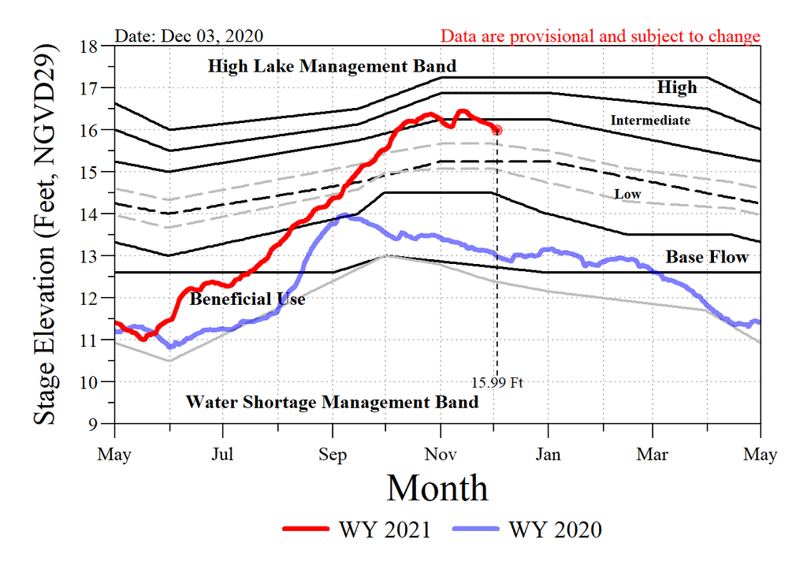

Lake Okeechobee daily average stage elevation for WY2021 (red line) relative to the Lake Okeechobee Regulation Schedule (LORS) .

Data are provisional and subject to change.

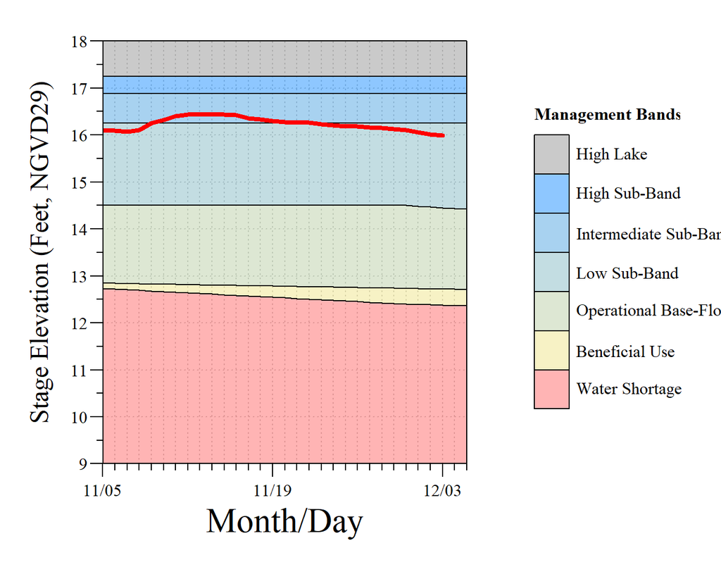

Lake Okeechobee daily average stage elevation for the last 30-days (red line) relative to the Lake Okeechobee Regulation Schedule (LORS) .

Data are provisional and subject to change.

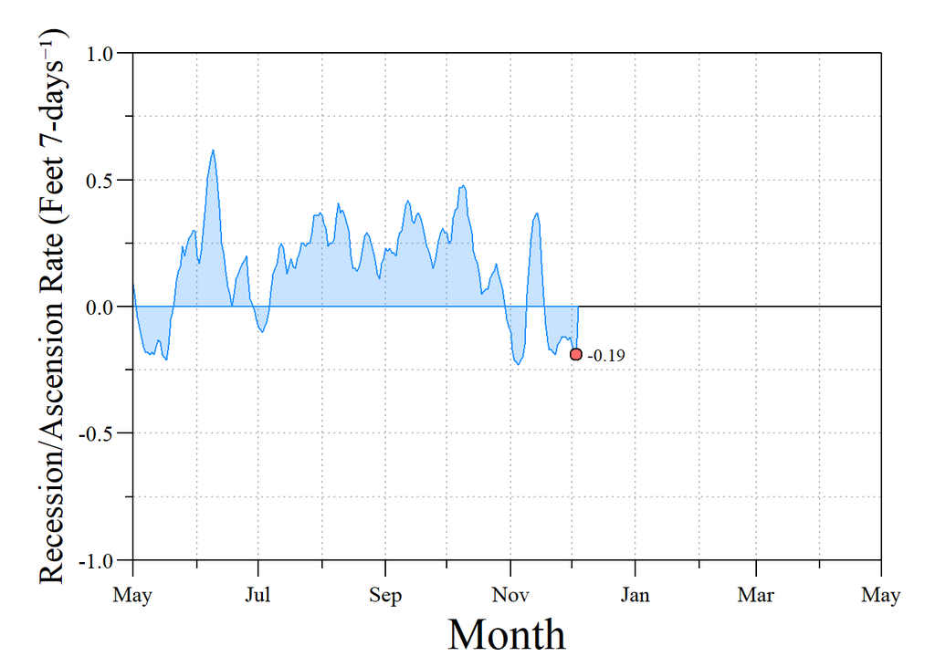

Lake Okeechobee 7-day water level recession/ascension rates during WY2021. The red-point identifes the recession/ascension rate for the period of 11/26/2020 - 12/03/2020. Negative values indicate falling water levels (recession) and positive values indicate raising water level (ascension) during this 7-day period .

Data are provisional and subject to change.

### *Precipitation*

[figure not shown]

District Wide Precipitation Forecast for 12/05/2020 (Data Source: [SFWMD](https://www.sfwmd.gov/weather-radar/sfwmd-forecast)).

[figure not shown]

District Wide Precipitation from 12/03/2020 to 12/04/2020. (Data Source: [SFWMD](https://www.sfwmd.gov/weather-radar/rainfall-historical/daily)).

[figure not shown]

NOAA offical 30-day precipitation forecasts. (Data Source: [NOAA](https://www.cpc.ncep.noaa.gov/products/forecasts/month_to_season_outlooks.php)).

[figure not shown]

NOAA offical 3-month precipitation forecasts for Dec-Jan-Feb 2020/21. (Data Source: [NOAA](https://www.cpc.ncep.noaa.gov/products/forecasts/month_to_season_outlooks.php)).

#### Text Reports and Forecasts

Link to [SFWMD Text Forecast](https://www.sfwmd.gov/weather-radar/sfwmd-text-forecast)

Link to [USACE Lake Okeechobee and Vicinity Report](http://w3.saj.usace.army.mil/h2o/reports/r-oke.txt)

### *Flow and Salinity Data for the C-43/Caloosahatchee River and Estuary*

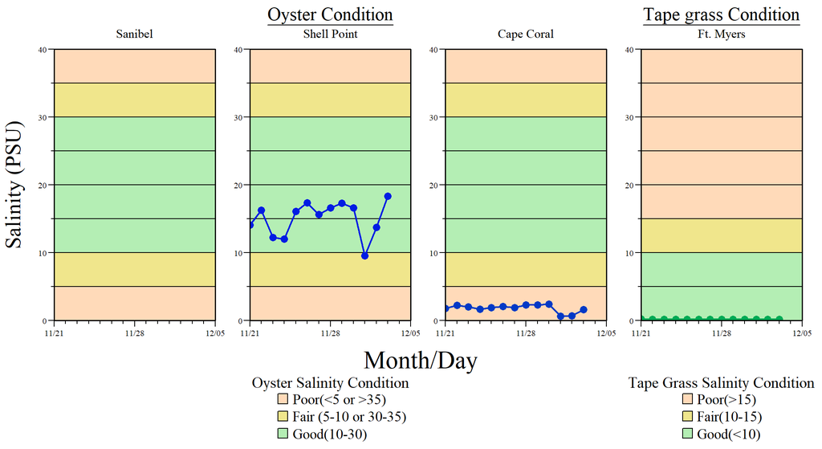

Daily average salinity data for the last 14-days from sampling locations within the tidal Caloosahatchee River Estuary relative to oyster health (Sanibel, Shell Point and Cape Coral) and tape grass (*Vallisneria americana*) health (Ft. Myers only) conditions.

Data are provisional and subject to change.

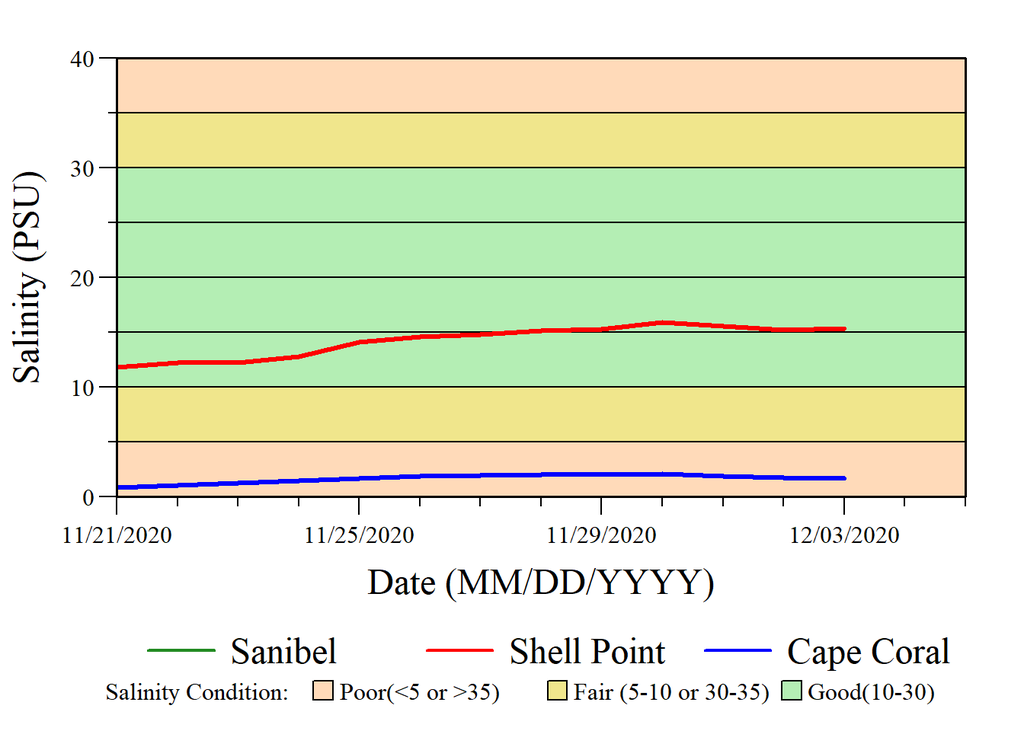

Moving 7-day average salinities observed at the Cape Coral, Shell Point and Sanibel salinity monitoring stations relative to Oyster salinity health conditions.

Data are provisional and subject to change.

[figure not shown]

Top: Daily relative floursence Chlorophyll and Phycocyanin observed at the floating sensor bouy at S-79 monitoring by USGS. Bottom: The relative ratio of Phycocyanin (Phyco) relative to Phyco and Chlorophyll (Chl).

Data are provisional and subject to change.

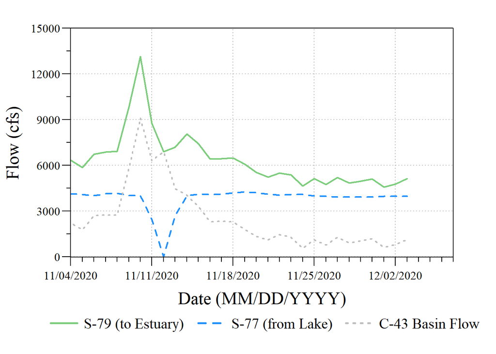

S-77 (from Lake Okeechobee) and S-79 (to Tidal Basin) flow data along the C-43 and Caloosahatchee River. C-43 Basin Flow was calculated as the difference from S-77 and S-79. Data Source: USGS.

Data are provisional and subject to change.

### *Flow and Salinity Data for the C-44/St. Lucie River and Estuary*

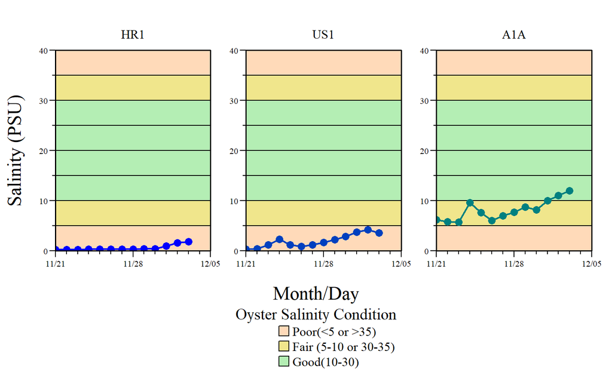

Daily average salinity data for the last 14-days from sampling locations within the St. Lucie Estuary relative to oyster health conditions.

Data are provisional and subject to change.

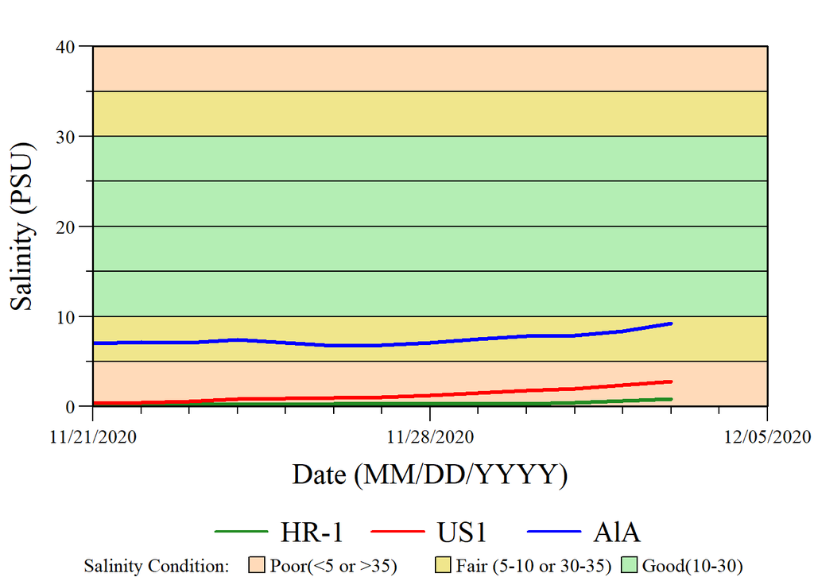

Moving 7-day average salinities observed at the US1, A1A and North Fork (HR1) salinity monitoring stations relative to Oyster salinity health conditions in the St. Lucie estuary.

Data are provisional and subject to change.

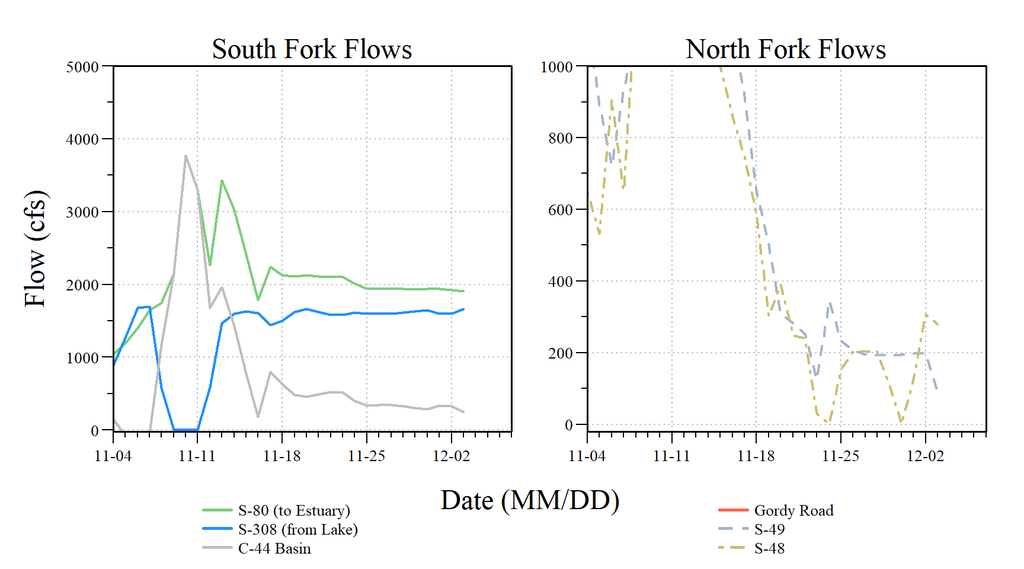

Left:S-80 (to Tidal Basin), S-308 (from Lake Okeechobee) and C-44 Basin flows (calculated as the difference from S-308 and S-80). Right: Gordy Road (from Ten-Mile Creek Basin), S-49 (from C-24 Basin) and S-48 (from C-23 Basin) flows. Data Source: SFWMD.

Data are provisional and subject to change.

### *Salinity Data for Florida Bay*

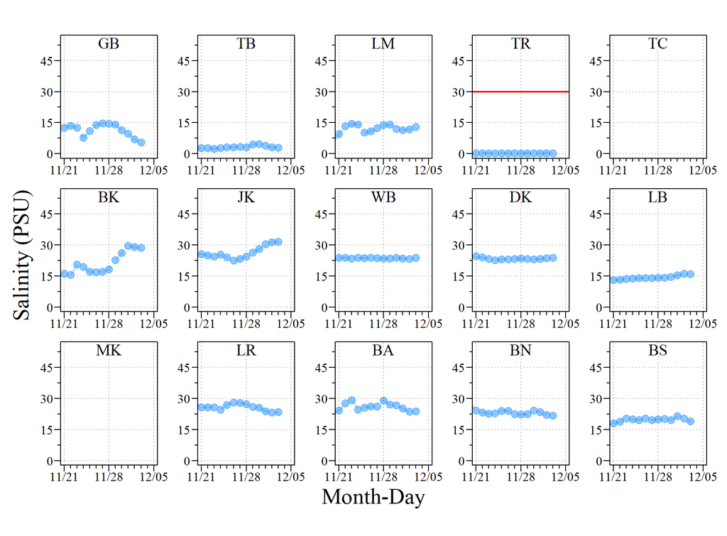

Daily average salinity data for the last 14-days from select sampling locations within Florida Bay.

Data are provisional and subject to change.

### *Monitoring Locations and Data Sources*

[interactive chart not shown]

Monitoring locations for Lake Okeechobee stage elevation and estuary salinity tracking.

[figure not shown]

Office of Ecosystem Projects